# Productfolio

Seunghee Im

2025-05-08

# Project Overview

In this project, I led analytics and user behavior strategy for **Productfolio**, a SaaS platform. My focus was on improving user acquisition, engagement, and conversion through behavioral analysis, persona development, and funnel visualization.

**Skills** **Demonstrated:**

- Behavior-based customer segmentation using Google Analytics 4 (GA4).
- Conversion funnel analysis with R and Excel.
- Descriptive analytics and visual storytelling-Content strategy and user engagement optimization.
- Data wrangling and visualization using ggplot2.

## 1. User Research & Traffic Optimization

### 1.1 Productfolio Signup Funnel (Feb 1 – Mar 31, 2025)

**Descriptive Analytics Used**

- User Count**: Number of users at each funnel step**
- Conversion Rate**: % of users moving to the next step**
- Bounce Rate: % of users lost between steps

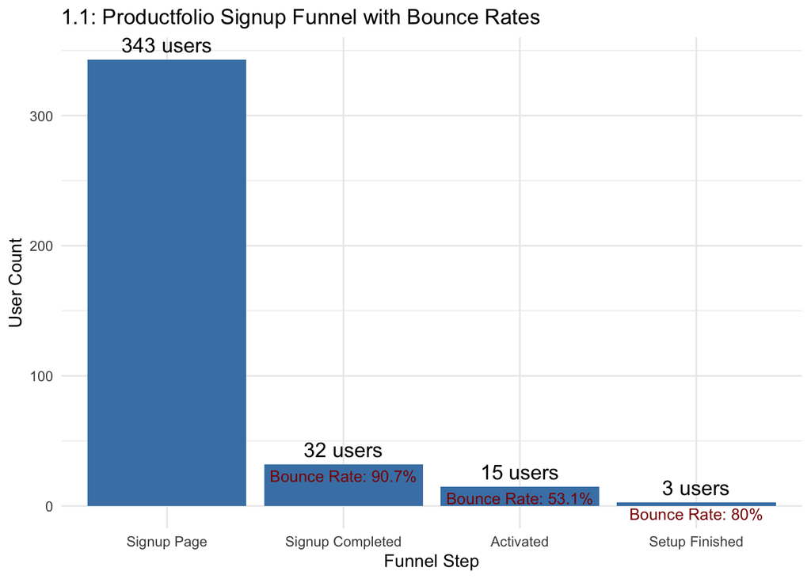

```r
library(ggplot2)

funnel_data <- data.frame(
  Step = factor(c("Signup Page", "Signup Completed", "Activated", "Setup Finished"),
                levels = c("Signup Page", "Signup Completed", "Activated", "Setup Finished")),
  Users = c(343, 32, 15, 3),
  BounceRate = c(NA, 90.7, 53.1, 80)
)

ggplot(funnel_data, aes(x = Step, y = Users)) +
  geom_col(fill = "steelblue") +
  geom_text(aes(label = paste0(Users, " users")), vjust = -0.5, size = 4.5) +
  geom_text(
    aes(label = ifelse(!is.na(BounceRate),
                       paste0("Bounce Rate: ", BounceRate, "%"),
                       "")),
    vjust = 1.5, color = "darkred", size = 3.5
  ) +
  labs(
    title = "1.1: Productfolio Signup Funnel with Bounce Rates",
    y = "User Count",
    x = "Funnel Step"
  ) +
  theme_minimal()
```

**Insights:**

- 90.7% of users dropped off between Signup Page → Signup Completed
- Only 20% of users completed Setup after Activation
- Indicates friction in both the signup and onboarding experience

**Recommendations:**

- Simplify form fields and clarify CTAs
- Add onboarding tutorials or checklists
- A/B test page messaging for improved clarity and motivation

### 1.2 Frequency of Key User Events

This chart highlights how often users perform key actions such as viewing pages or engaging with the site. It reveals top-of-funnel engagement vs. deeper interaction.

**Descriptive Analytics Used:**

- **Event Count**: Number of times each user event occurred
- **Comparative Frequency**: Ranked by popularity

```r
library(dplyr)
```

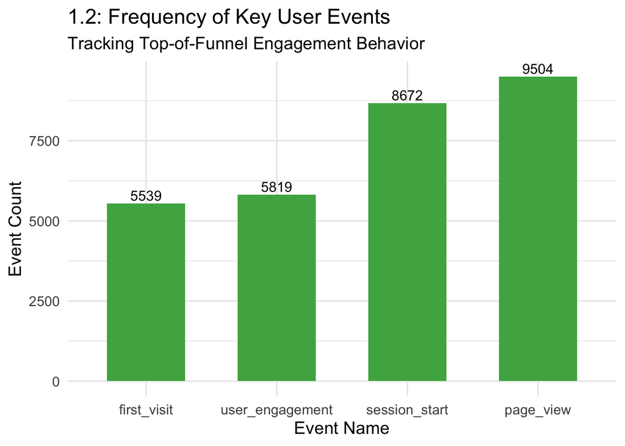

```r
Cleaned_Site_Events_Data <- data.frame(
  EventName = c("page_view", "session_start", "user_engagement", "first_visit"),
  EventCount = c(9504, 8672, 5819, 5539)
)

focus_events <- Cleaned_Site_Events_Data %>%
  filter(EventName %in% c("page_view", "session_start", "user_engagement", "first_visit"))

ggplot(focus_events, aes(x = reorder(EventName, EventCount), y = EventCount)) +
  geom_bar(stat = "identity", fill = "#4CAF50", width = 0.6) +
  geom_text(aes(label = EventCount), vjust = -0.3, size = 4) +
  labs(
    title = "1.2: Frequency of Key User Events",
    subtitle = "Tracking Top-of-Funnel Engagement Behavior",
    x = "Event Name",
    y = "Event Count"
  ) +
  theme_minimal(base_size = 14)
```

**Insights:**

- High counts for `page_view` and `session_start` indicate strong acquisition.
- Lower numbers for `first_visit` and `user_engagement` suggest a need to improve early interaction.

## 2. Content Performance Analysis

### 2.1 Top 5 Most Viewed Pages

This chart showcases the pages that receive the most views, helping identify entry points and SEO-optimized content.

**Descriptive Analytics Used:**

- **Pageviews**: Count of page views per path
- **Volume Ranking**: Ordered from most to least viewed

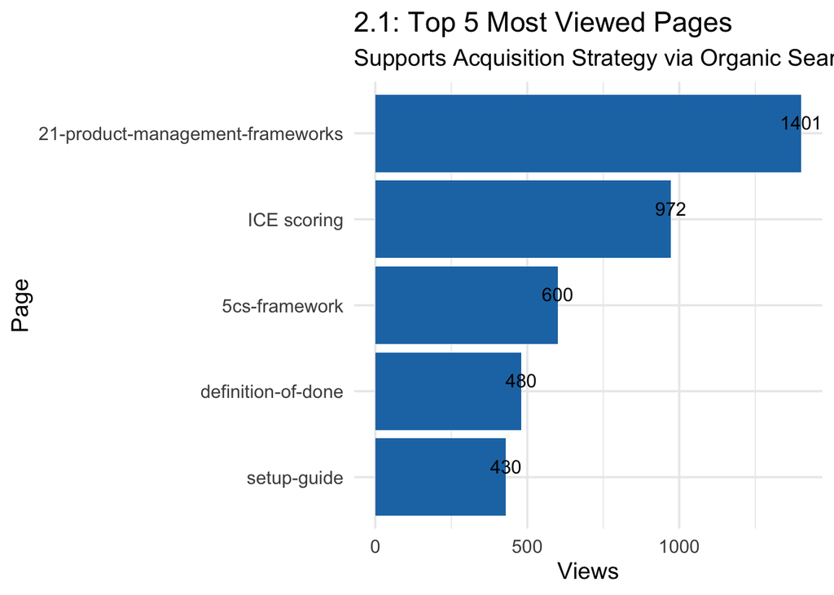

```r
Cleaned_Pageviews <- data.frame(
  PagePath = c("21-product-management-frameworks", "ICE scoring", "5cs-framework", "definition-of-done", "setup-guide"),
  Views = c(1401, 972, 600, 480, 430),
  AvgEngagementTime = c(100, 85, 90, 60, 40)
)

top_views <- Cleaned_Pageviews %>%
  arrange(desc(Views)) %>%
  head(5)

ggplot(top_views, aes(x = reorder(PagePath, Views), y = Views)) +
  geom_bar(stat = "identity", fill = "#1f77b4") +
  geom_text(aes(label = Views), vjust = -0.3, size = 4) +
  labs(
    title = "2.1: Top 5 Most Viewed Pages",
    subtitle = "Supports Acquisition Strategy via Organic Search",
    x = "Page",
    y = "Views"
  ) +
  theme_minimal(base_size = 14) +
  coord_flip()
```

**Insights:**

- “21-product-management-frameworks” and “ICE scoring” attract the most traffic
- Likely strong organic search performance

**Recommendation:** Add CTAs to convert high-traffic pages into lead generators.